# **MATH 3190 Homework 10**

### Part i (6 points)

Use the `checkresiduals()` function in the `forecast` library to create a residual plot, an autocorrelation plot, and a histogram for the residuals. The input to this function should be your model fit with the `auto.arima()` function. Comment on whether the assumptions seem to be satisfied here. If you’d like, you can make a QQ-plot as well, but the histogram contains the same information.

Note: this function will also give you information from the Ljung-Box test, which tests if the residuals exhibit autocorrelation. A large p-value means we have no evidence of autocorrelation.

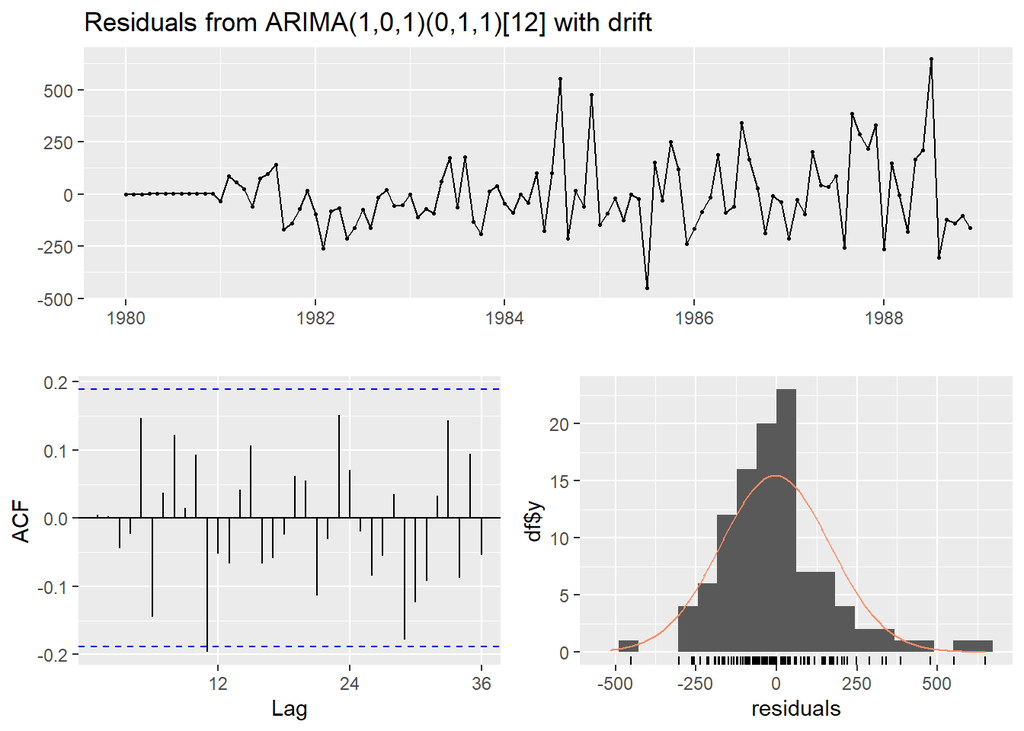

```
    Ljung-Box test

data:  Residuals from ARIMA(1,0,1)(0,1,1)[12] with drift
Q* = 19.463, df = 19, p-value = 0.4275

Model df: 3.   Total lags used: 22
```

```r
# Diagnostic plots for the NEW seasonal ARIMA model residuals
checkresiduals(wine_fit)
```

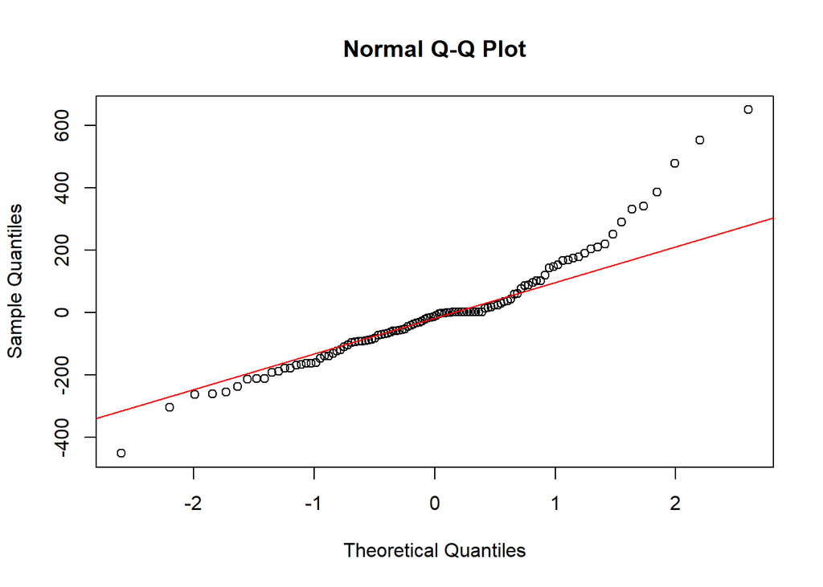

```r
# QQ-plot to check for improved normality
res <- residuals(wine_fit)
qqnorm(res)
qqline(res, col = "red")
```